# Examples for AUC functions

Devin

July 19, 2014

```r
libraries <- c("knitr", "ggplot2", "PKPDdatasets", "PKPDmisc", "dplyr")
suppressMessages(sapply(libraries, require, character.only=T))
```

```
##        knitr      ggplot2 PKPDdatasets     PKPDmisc        dplyr
##         TRUE         TRUE         TRUE         TRUE         TRUE
```

```r
opts_chunk$set(tidy=F)
```

Use the terribly named `sd_oral_richpk` dataset from my `PKPDdatasets` package and `AUC_partial` and `AUC_inf` functions from `PKPDmisc`

available via:

```
library(devtools)
install_github("dpastoor/PKPDdatasets")
install_github("dpastoor/PKPDmisc")
```

```r
pkdata <- sd_oral_richpk
head(pkdata)
```

```
##   ID Time  Amt   Conc  Age Weight Gender     Race Dose
## 1  1 0.00 5000  0.000 56.1   94.2   Male Hispanic 5000
## 2  1 0.25    0  8.613 56.1   94.2   Male Hispanic 5000
## 3  1 0.50    0 19.437 56.1   94.2   Male Hispanic 5000
## 4  1 1.00    0 34.007 56.1   94.2   Male Hispanic 5000
## 5  1 2.00    0 30.229 56.1   94.2   Male Hispanic 5000
## 6  1 3.00    0 31.300 56.1   94.2   Male Hispanic 5000
```

```r
#convert all columns to caps for easier recall
names(pkdata) <- toupper(names(pkdata))
```

## Basic summary and plots to get a feel for the data

```r
pkdata %>% filter(!duplicated(ID)) %>%  select(AGE, WEIGHT, GENDER, RACE) %>% summary
```

```
##       AGE           WEIGHT        GENDER          RACE
##  Min.   :38.3   Min.   :54.9   Female:15   Asian    : 7
##  1st Qu.:46.7   1st Qu.:64.2   Male  :35   Black    :12
##  Median :50.8   Median :71.2               Caucasian:13
##  Mean   :50.5   Mean   :71.0               Hispanic : 8
##  3rd Qu.:54.5   3rd Qu.:76.7               Other    :10
##  Max.   :60.6   Max.   :94.2
```

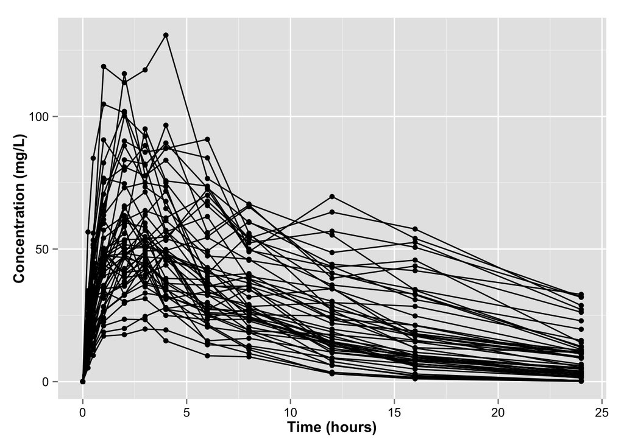

```r
ggdat  <- ggplot(pkdata, aes(x = TIME, y = CONC, group = ID))
ggdat + geom_line() + geom_point() +
  base_theme() + xlab("Time (hours)") + ylab("Concentration (mg/L)")
```

# AUC function examples

## AUC_partial examples

Get summary of AUC 0-tlast

```r
pkdata %>%
  group_by(ID) %>%
  summarize(AUC0_tlast = AUC_partial(TIME, CONC, partialtime = max(TIME))) %>%
  head(n = 10)
```

```
## Source: local data frame [10 x 2]
##
##    ID AUC0_tlast
## 1   1      385.6
## 2   2     1203.5
## 3   3      466.3
## 4   4     1219.6
## 5   5      487.6
## 6   6      295.2
## 7   7      739.0
## 8   8      453.8
## 9   9      699.0
## 10 10      161.4
```

If you want to carry additional covariates for later summary add them as grouping variables

```r
aucs_gender_race  <- pkdata %>%
  group_by(ID, GENDER, RACE) %>%
  summarize(AUC0_tlast = AUC_partial(TIME, CONC, partialtime = max(TIME)))
aucs_gender_race %>% head(n = 10)
```

```
## Source: local data frame [10 x 4]
## Groups: ID, GENDER
##
##    ID GENDER      RACE AUC0_tlast
## 1   1   Male  Hispanic      385.6
## 2   2   Male Caucasian     1203.5
## 3   3   Male     Other      466.3
## 4   4 Female Caucasian     1219.6
## 5   5 Female Caucasian      487.6
## 6   6   Male  Hispanic      295.2
## 7   7   Male     Other      739.0
## 8   8   Male     Asian      453.8
## 9   9 Female     Other      699.0
## 10 10   Male     Other      161.4
```

You can then do additional summary statistics on a category (or combinations of categories)

```r
aucs_gender_race %>% group_by(GENDER) %>%
  summarize(meanAUC = mean(AUC0_tlast))
```

```
## Source: local data frame [2 x 2]
##
##   GENDER meanAUC
## 1 Female   746.3
## 2   Male   650.7
```

```r
aucs_gender_race %>% group_by(GENDER,RACE) %>%
  summarize(meanAUC = mean(AUC0_tlast))
```

```
## Source: local data frame [10 x 3]
## Groups: GENDER
##
##    GENDER      RACE meanAUC
## 1  Female     Asian   655.8
## 2  Female     Black   809.9
## 3  Female Caucasian   570.5
## 4  Female  Hispanic  1317.6
## 5  Female     Other   620.6
## 6    Male     Asian   751.4
## 7    Male     Black   625.5
## 8    Male Caucasian   833.7
## 9    Male  Hispanic   385.9
## 10   Male     Other   638.7
```

## AUC_inf examples

AUC_inf is a bit more complicated internally than AUC partial, in that there are multiple types of output you can get. This is actually a bad practice, and I will eventually re-write to have two separate functions depending on what the user wants.

By default, the `AUC_infonly` argument is `TRUE` so only a vector of AUC0_infinity values are returned. This makes it usable inside of dplyr/plyr as you can only have single vector output.

```r
aucinfs_race  <- pkdata %>%
  group_by(ID,RACE) %>%
  summarize(AUC0_inf = AUC_inf(TIME, CONC))
aucinfs_race %>% head(n = 10)
```

```
## Source: local data frame [10 x 3]
## Groups: ID
##
##    ID      RACE AUC0_inf
## 1   1  Hispanic    445.3
## 2   2 Caucasian   2495.1
## 3   3     Other    482.2
## 4   4 Caucasian   1789.2
## 5   5 Caucasian    516.4
## 6   6  Hispanic    342.6
## 7   7     Other    877.0
## 8   8     Asian    472.8
## 9   9     Other    817.7
## 10 10     Other    162.9
```

However, many times people want additional information, such as the number of points selected in the terminal phase, the adjusted R squared, lambda_z for t1/2, etc. So right now AUC_inf can also output a dataframe containing:

- AUClast
- AUCinf
- Extra_percent
- Adj.R.Sq
- Lambda_z
- Num_points_lambda_z

The easiest way to do so is via the `do` function in dplyr

```r
AUCinf <- pkdata %>% group_by(ID) %>%
  do(AUC_inf(.$TIME, .$CONC, AUCinf_only = F))
head(AUCinf)
```

```
## Source: local data frame [6 x 7]
## Groups: ID
##
##   ID AUClast AUCinf Extra_percent Adj.R.Sq Lambda_z Num_points_lambda_z
## 1  1   385.6  445.3        15.493   0.9710  0.08866                   5
## 2  2  1203.5 2495.1       107.322   0.9519  0.02547                   3
## 3  3   466.3  482.2         3.409   0.9959  0.14692                   5
## 4  4  1219.6 1789.2        46.700   0.7822  0.04594                   5
## 5  5   487.6  516.4         5.922   0.9884  0.12339                   4
## 6  6   295.2  342.6        16.028   0.9997  0.08494                   3
```

You can also ask for them as individual columns inside of `summarize` and `mutate` commands by asking for specific column names

```r
aucinfs_extra  <- pkdata %>%
  group_by(ID,RACE) %>%
  summarize(AUC0_inf = AUC_inf(TIME, CONC),
            extra_percent = round(AUC_inf(TIME, CONC, AUCinf_only = F)[["Extra_percent"]],2))
aucinfs_extra %>% head(n = 10)
```

```
## Source: local data frame [10 x 4]
## Groups: ID
##
##    ID      RACE AUC0_inf extra_percent
## 1   1  Hispanic    445.3         15.49
## 2   2 Caucasian   2495.1        107.32
## 3   3     Other    482.2          3.41
## 4   4 Caucasian   1789.2         46.70
## 5   5 Caucasian    516.4          5.92
## 6   6  Hispanic    342.6         16.03
## 7   7     Other    877.0         18.67
## 8   8     Asian    472.8          4.18
## 9   9     Other    817.7         16.98
## 10 10     Other    162.9          0.89
```

A general rule of thumb is you shouldn’t have more than ~20% extra (that is `AUCtlast_inf - AUC0_tlast`) to make a valid inference about AUC0_inf, else you are extrapolating too much.

### number of points used in AUC_inf extrapolation

When the extrapolation from tlast to inf is happening, a linear model is fit to 3, 4, 5… of the last points to figure out which provides the best fit and use that to extrapolate from tlast to infinity. By default, the function only checks 3, 4, 5 points. However if you have rich sampling in the terminal phase and want to fit more you can specify via the `last_points` argument.

```r
pkdata %>%
  group_by(ID,RACE) %>%
  summarize(AUC0_inf = AUC_inf(TIME, CONC, last_points = c(3, 4, 5, 6, 7)),
            numpoints_extrap = AUC_inf(TIME, CONC,
                                       last_points = c(3, 4, 5, 6, 7),
                                       AUCinf_only = F)[["Num_points_lambda_z"]]) %>%
  head(n = 10)
```

```
## Source: local data frame [10 x 4]
## Groups: ID
##
##    ID      RACE AUC0_inf numpoints_extrap
## 1   1  Hispanic    448.1                7
## 2   2 Caucasian   2495.1                3
## 3   3     Other    481.9                7
## 4   4 Caucasian   1702.5                7
## 5   5 Caucasian    516.4                4
## 6   6  Hispanic    342.6                3
## 7   7     Other    877.0                5
## 8   8     Asian    472.8                3
## 9   9     Other    817.7                3
## 10 10     Other    162.9                3
```